# Lab 15 : Update of GTDB and ggtree with your taxonomic group

## Learning objectives

- Visualizing and annotating trees

This lab draws on examples in

- [Data Integration, Manipulation and Visualization of Phylogenetic Trees](https://yulab-smu.top/treedata-book/)
- [ggtreeExtra](https://bioconductor.org/packages/devel/bioc/vignettes/ggtreeExtra/inst/doc/ggtreeExtra.html)
- [ape package documentation](https://cran.r-project.org/web//packages/ape/ape.pdf)
- [phytools package documentation](https://cran.r-project.org/web/packages/phytools/phytools.pdf)
- [Working with Trees using the ape * Package](https://eeob-macroevolution.github.io/Practicals/Intro_to_Phylo/intro_to_phylo.html)
- [Introduction to phylogenies in R](http://phytools.org/eqg/Exercise_3.2/)
- Drawing Phylogenies in R: Basic and Advanced Features With ape
- [gtdb forum](https://forum.gtdb.ecogenomic.org/)
- [gtdb commands](https://ecogenomics.github.io/GTDBTk/commands/de_novo_wf.html)

Two of the packages are available through Bioconductor

```r
if (!require("BiocManager", quietly = TRUE))
    install.packages("BiocManager")

BiocManager::install("treeio")
BiocManager::install("ggtreeExtra")
```

## Load libraries

```r
library(tidyverse)
library(knitr)
library(ggtree)
library(TDbook) #A Companion Package for the Book "Data Integration, Manipulation and Visualization of Phylogenetic Trees" by Guangchuang Yu (2022, ISBN:9781032233574).
library(ggimage)
library(rphylopic)
library(treeio)
library(tidytree)
library(ape)
library(TreeTools)
library(phytools)
library(ggnewscale)
library(ggtreeExtra)
library(ggstar)
```

## Reading in files

### MAG table

Let’s load the MAG table with the new GTDB annotations with the updated taxonomy database

```r
NEON_MAGs <- read_csv("data/NEON/GOLD_Study_ID_Gs0161344_NEON_2024_4_21.csv") %>%
  # remove columns that are not needed for data analysis
  select(-c(`GOLD Study ID`, `Bin Methods`, `Created By`, `Date Added`, `Bin Lineage`)) %>%
  # create a new column with the Assembly Type
  mutate("Assembly Type" = case_when(`Genome Name` == "NEON combined assembly" ~ `Genome Name`,
                            TRUE ~ "Individual")) %>%
  mutate_at("Assembly Type", str_replace, "NEON combined assembly", "Combined") %>%
  mutate_at("GTDB-Tk Taxonomy Lineage", str_replace, "d__", "") %>%
  mutate_at("GTDB-Tk Taxonomy Lineage", str_replace, "p__", "") %>%
  mutate_at("GTDB-Tk Taxonomy Lineage", str_replace, "c__", "") %>%
  mutate_at("GTDB-Tk Taxonomy Lineage", str_replace, "o__", "") %>%
  mutate_at("GTDB-Tk Taxonomy Lineage", str_replace, "f__", "") %>%
  mutate_at("GTDB-Tk Taxonomy Lineage", str_replace, "g__", "") %>%
  mutate_at("GTDB-Tk Taxonomy Lineage", str_replace, "s__", "") %>%
  separate(`GTDB-Tk Taxonomy Lineage`, c("Domain", "Phylum", "Class", "Order", "Family", "Genus", "Species"), ";", remove = FALSE) %>%
  mutate_at("Domain", na_if,"") %>%
  mutate_at("Phylum", na_if,"") %>%
  mutate_at("Class", na_if,"") %>%
  mutate_at("Order", na_if,"") %>%
  mutate_at("Family", na_if,"") %>%
  mutate_at("Genus", na_if,"") %>%
  mutate_at("Species", na_if,"") %>%

  # Get rid of the the common string "Soil microbial communities from "
  mutate_at("Genome Name", str_replace, "Terrestrial soil microbial communities from ", "") %>%
  # Use the first `-` to split the column in two
  separate(`Genome Name`, c("Site","Sample Name"), " - ") %>%
  # Get rid of the the common string "S-comp-1"
  mutate_at("Sample Name", str_replace, "-comp-1", "") %>%
  # separate the Sample Name into Site ID and plot info
  separate(`Sample Name`, c("Site ID","subplot.layer.date"), "_", remove = FALSE,) %>%
  # separate the plot info into 3 columns
  separate(`subplot.layer.date`, c("Subplot", "Layer", "Date"), "-")
```

### Metagenome information

We are going to remove the `re-annotation` and `WREF plot` samples from the data set you export last week from IMG.

```r
NEON_metagenomes <- read_tsv("data/NEON/exported_img_data_Gs0161344_NEON.tsv") %>%
  select(-c(`Domain`, `Sequencing Status`, `Sequencing Center`)) %>%
  rename(`Genome Name` = `Genome Name / Sample Name`) %>%
  filter(str_detect(`Genome Name`, 're-annotation', negate = T)) %>%
  filter(str_detect(`Genome Name`, 'WREF plot', negate = T))
```

Now let’s reformat `Genome Name` as we did for the above MAG table

```r
NEON_metagenomes <- NEON_metagenomes %>%
  # Get rid of the the common string "Soil microbial communities from "
  mutate_at("Genome Name", str_replace, "Terrestrial soil microbial communities from ", "") %>%
  # Use the first `-` to split the column in two
  separate(`Genome Name`, c("Site","Sample Name"), " - ") %>%
  # Get rid of the the common string "-comp-1"
  mutate_at("Sample Name", str_replace, "-comp-1", "") %>%
  # separate the Sample Name into Site ID and plot info
  separate(`Sample Name`, c("Site ID","subplot.layer.date"), "_", remove = FALSE,) %>%
  # separate the plot info into 3 columns
  separate(`subplot.layer.date`, c("Subplot", "Layer", "Date"), "-")
```

### NEON Chemistry data

```r
NEON_chemistry <- read_tsv("data/NEON/neon_plot_soilChem1_metadata.tsv") %>%
  # remove -COMP from genomicsSampleID
  mutate_at("genomicsSampleID", str_replace, "-COMP", "")
```

### Join the NEON MAG, metagenome and chemistry dataframes into a single data fram

```r
NEON_MAGs_metagenomes_chemistry <- NEON_MAGs %>%
  left_join(NEON_metagenomes, by = "Sample Name") %>%
  left_join(NEON_chemistry, by = c("Sample Name" = "genomicsSampleID")) %>%
  rename("label" = "Bin ID")
```

### Read in the tree files from GTDB

```r
tree_arc <- read.tree("data/NEON/gtdbtk.ar53.decorated.tree")
tree_bac <- read.tree("data/NEON/gtdbtk.bac120.decorated.tree")
```

### Getting your subtree

You first need to find the internal node on the tree corresponding to your Domain, Phylum or Class. Below is an expample

```r
# Make a vector with the internal node labels
node_vector_bac = c(tree_bac$tip.label,tree_bac$node.label)

# Search for your Phylum or Class to get the node
grep("Chloroflexota", node_vector_bac, value = TRUE)
```

```
## [1] "'0.996:p__Chloroflexota'"
```

```r
match(grep("Chloroflexota", node_vector_bac, value = TRUE), node_vector_bac)
```

```
## [1] 1712
```

```r
# First need to preorder tree before extracting. N
tree_bac_preorder <- Preorder(tree_bac)
tree_Chloroflexota <- Subtree(tree_bac_preorder, 1712)
```

### Filter NEON table to taxonomic group or site

```r
NEON_MAGs_Chloroflexota <- NEON_MAGs_metagenomes_chemistry %>%
  filter(Phylum == "Chloroflexota")
```

## Tree graphs

### Basic rectangular

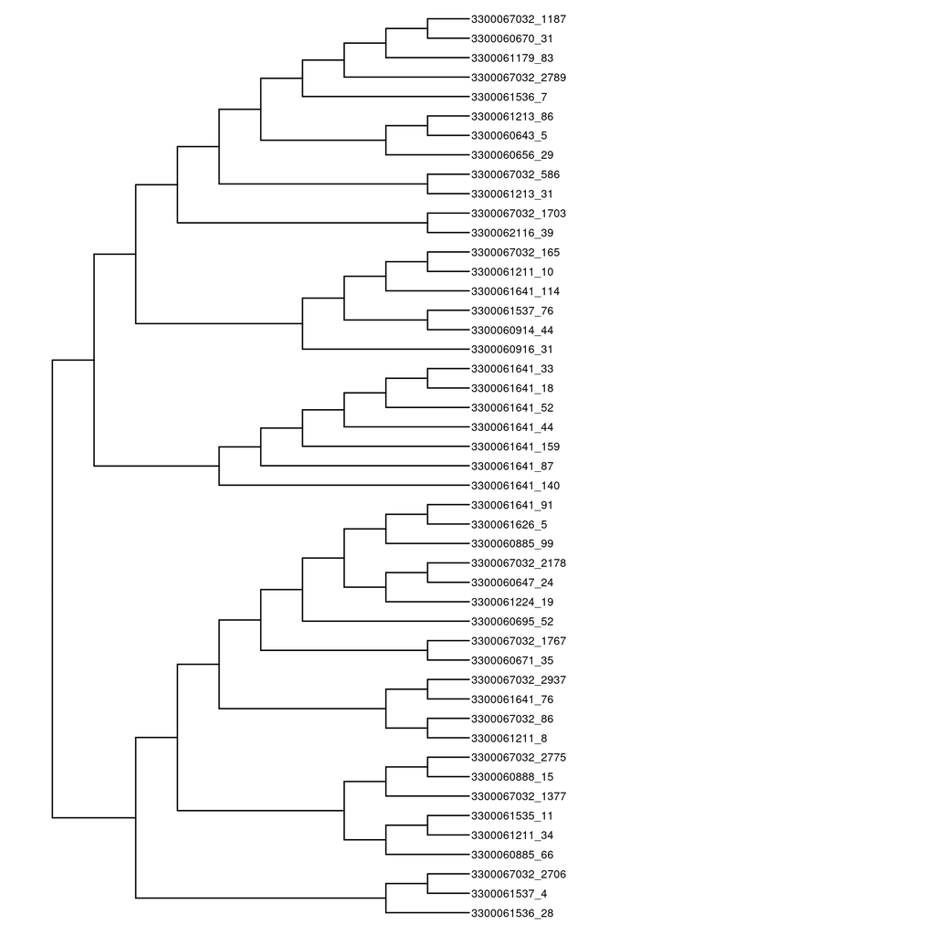

```r
ggtree(tree_Chloroflexota) +
  geom_tiplab(size=3) +
  xlim(0,20)
```

### Basic circular

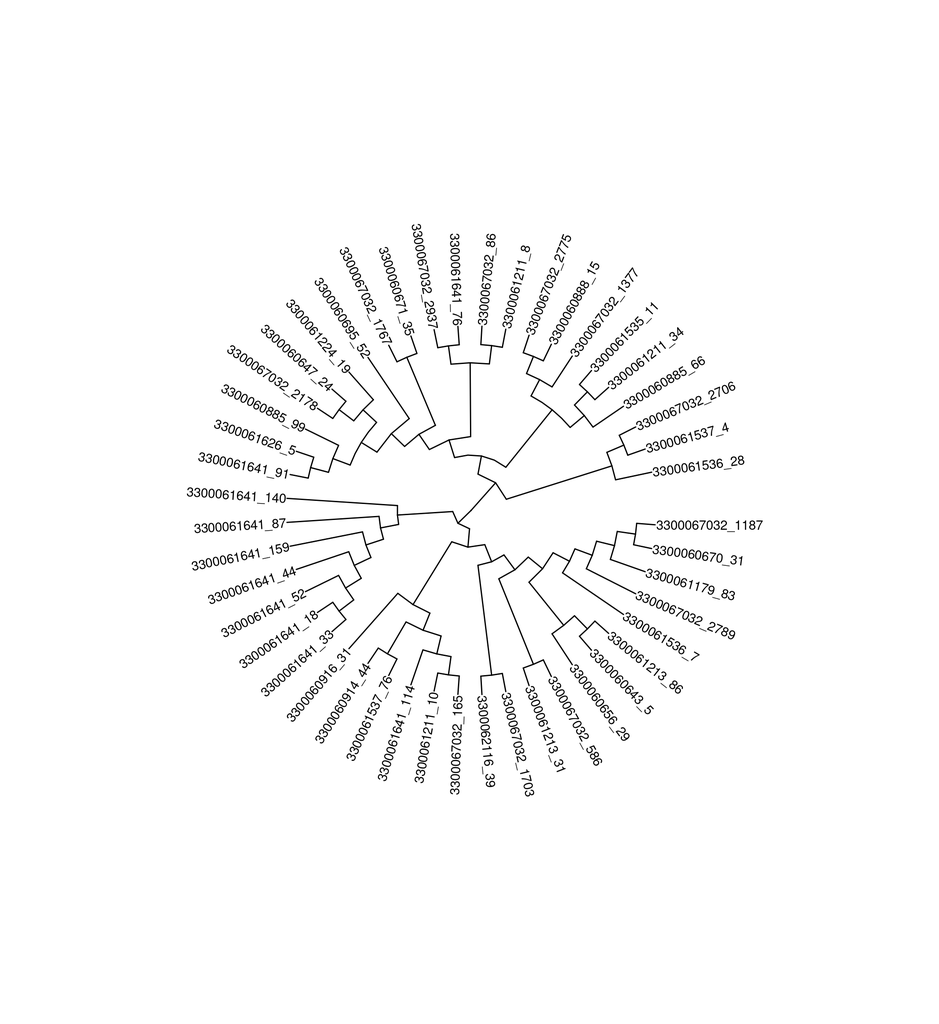

```r
ggtree(tree_Chloroflexota, layout="circular") +
  geom_tiplab(aes(angle=angle))+
    theme_tree() +
    xlim(0,20)
```

Circular with taxonomic group highlighted

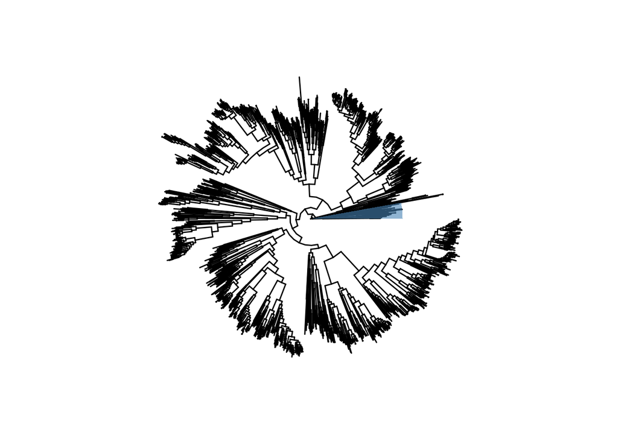

```r
ggtree(tree_bac, layout="circular") +
    geom_hilight(node=1712, fill="steelblue", alpha=.6)
```

### Circular no branch lengths taxonomic group labeled

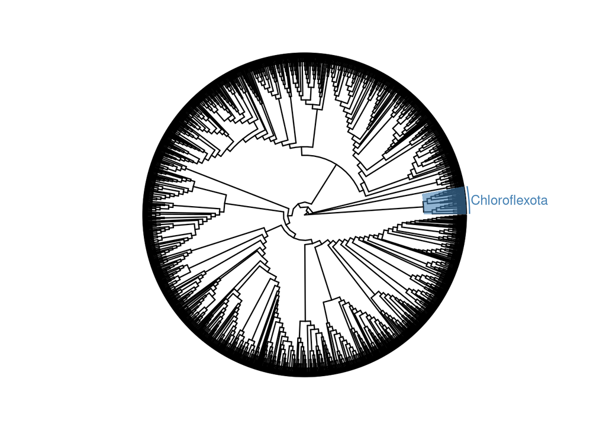

```r
ggtree(tree_bac, layout="circular", branch.length="none") +
    geom_hilight(node=1712, fill="steelblue", alpha=.6) +
    geom_cladelab(node=1712, label="Chloroflexota", align=TRUE,
                  offset = 0, textcolor='steelblue', barcolor='steelblue')
```

### Circular no branch lengths taxonomic group collapsed

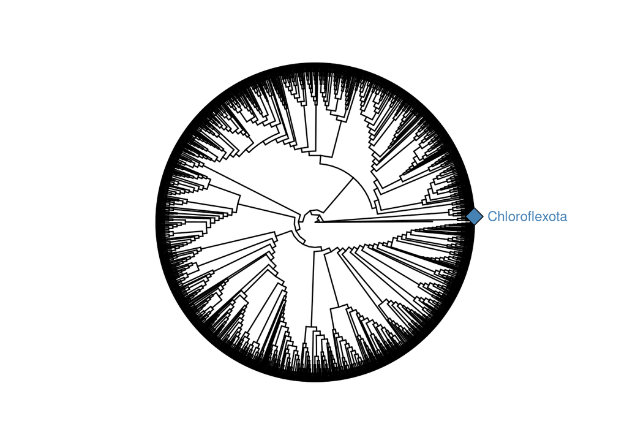

```r
ggtree(tree_bac, layout="circular", branch.length="none") %>%
  collapse(node=1712) +
  geom_point2(aes(subset=(node==55)), shape=23, size=5, fill='steelblue') +
  geom_cladelab(node=55, label="Chloroflexota", align=TRUE,
                  offset = 2, textcolor='steelblue')
```

### Circular no branch lengths taxonomic group collapsed as triangle and labeled

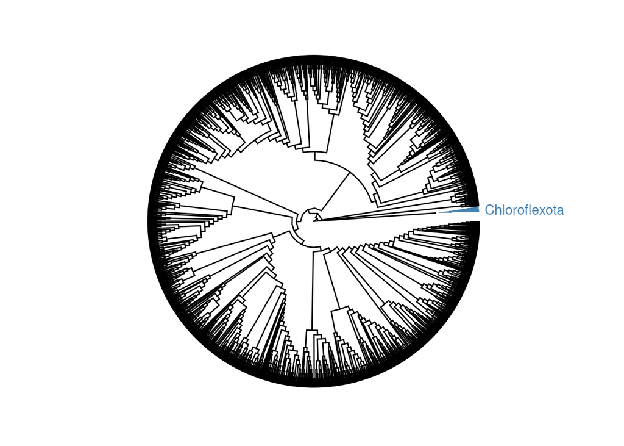

```r
p <- ggtree(tree_bac, layout="circular", branch.length="none")
scaleClade(p, 1712, .2) %>% collapse(1712, 'min', fill="steelblue")  +
  geom_cladelab(node=1712, label="Chloroflexota", align=TRUE,
                  offset = 0.2, textcolor='steelblue')
```

### Adding data to your tree

Note the special symbol `%<+%`. This is for joining the tree object with your data

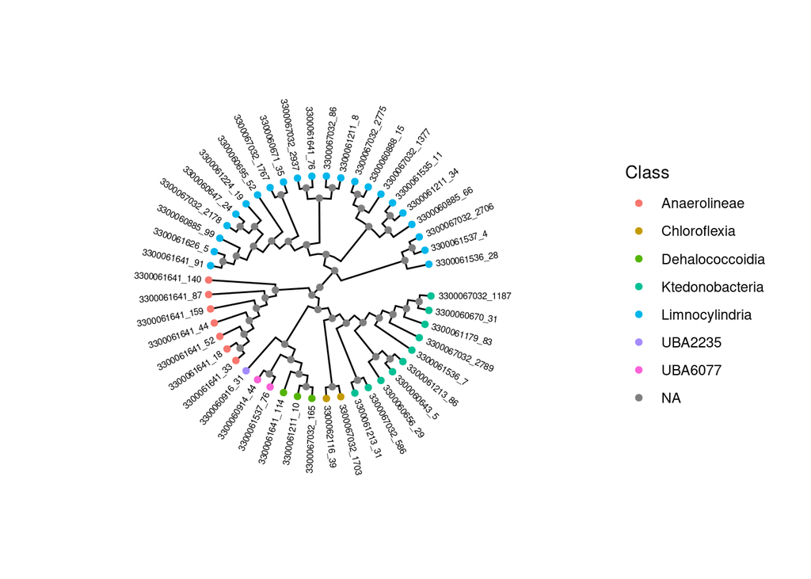

```r
ggtree(tree_Chloroflexota, layout="circular")  %<+%
  NEON_MAGs_metagenomes_chemistry +
  geom_tiplab(size=2, hjust=-.1) +
  xlim(0,20) +
  geom_point(mapping=aes(color=Class))
```

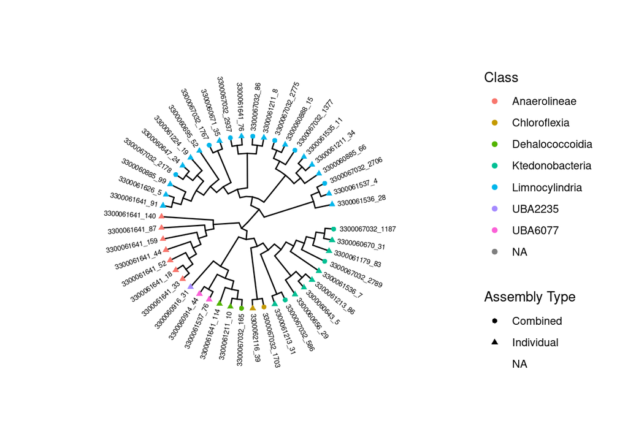

```r
ggtree(tree_Chloroflexota, layout="circular")  %<+%
  NEON_MAGs_metagenomes_chemistry +
  geom_tiplab(size=2, hjust=-.1) +
  xlim(0,20) +
  geom_point(mapping=aes(color=Class, shape = `Assembly Type`))
```

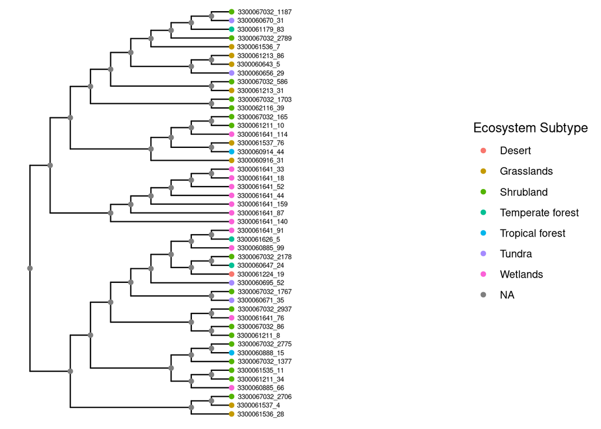

```r
ggtree(tree_Chloroflexota)  %<+%
  NEON_MAGs_metagenomes_chemistry +
  geom_tiplab(size=2, hjust=-.1) +
  xlim(0,20) +
  geom_point(mapping=aes(color=`Ecosystem Subtype`))
```

### Adding a gradient to your tree

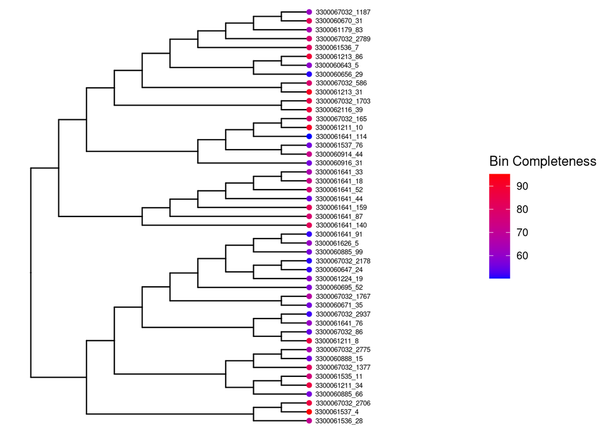

```r
ggtree(tree_Chloroflexota)  %<+%
  NEON_MAGs_metagenomes_chemistry +
  geom_tippoint(aes(colour=`Bin Completeness`)) +
  scale_colour_gradient(low='blue', high='red') +
  geom_tiplab(size=2, hjust=-.1) +
  xlim(0,15)
```

### Circular tree with data

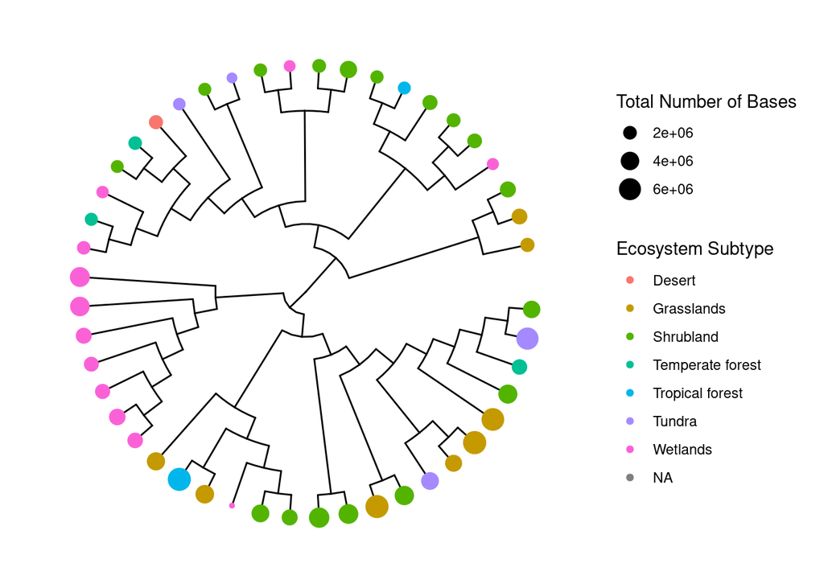

```r
ggtree(tree_Chloroflexota, layout="circular")  %<+%
  NEON_MAGs_metagenomes_chemistry +
  geom_point2(mapping=aes(color=`Ecosystem Subtype`, size=`Total Number of Bases`))
```

```r
  # geom_point2 is for circular trees
```

### Multiple graphs in the same panel

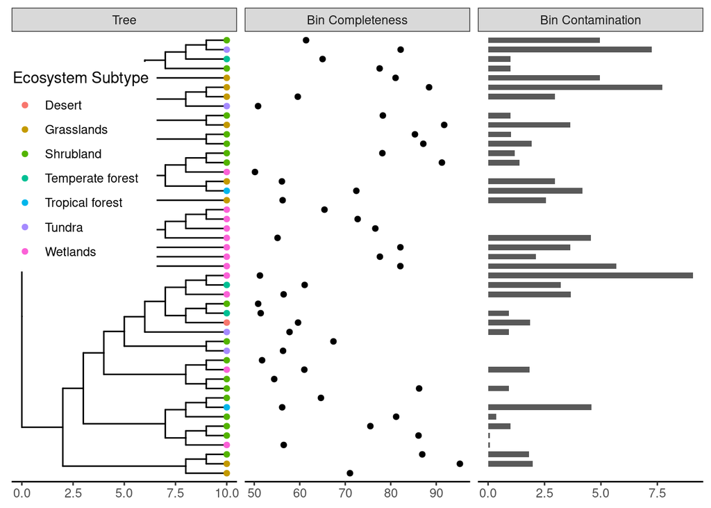

```r
# For unknown reasons the following does not like blank spaces in the names
NEON_MAGs_metagenomes_chemistry_noblank <- NEON_MAGs_metagenomes_chemistry %>%
  rename("AssemblyType" = "Assembly Type") %>%
  rename("BinCompleteness" = "Bin Completeness") %>%
  rename("BinContamination" = "Bin Contamination") %>%
  rename("TotalNumberofBases" = "Total Number of Bases") %>%
  rename("EcosystemSubtype" = "Ecosystem Subtype")

ggtree(tree_Chloroflexota)  %<+%
  NEON_MAGs_metagenomes_chemistry +
  geom_tippoint(aes(colour=`Ecosystem Subtype`)) +

# For unknown reasons the following does not like blank spaces in the names
  geom_facet(panel = "Bin Completeness", data = NEON_MAGs_metagenomes_chemistry_noblank, geom = geom_point,
      mapping=aes(x = BinCompleteness)) +
  geom_facet(panel = "Bin Contamination", data = NEON_MAGs_metagenomes_chemistry_noblank, geom = geom_col,
                aes(x = BinContamination), orientation = 'y', width = .6) +
  theme_tree2(legend.position=c(.1, .7))
```

### Adding outer rings to a circular tree

[output not shown]

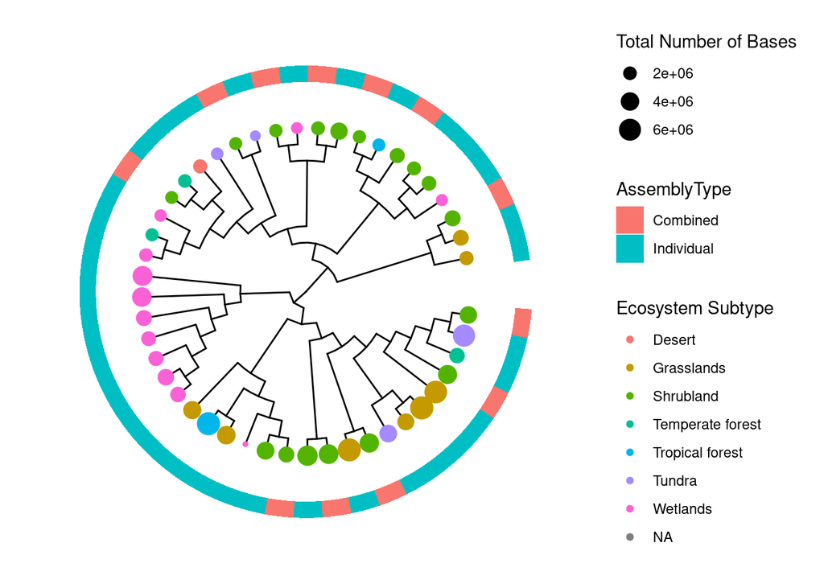

```r
ggtree(tree_Chloroflexota, layout="circular", branch.length="none") %<+%
  NEON_MAGs_metagenomes_chemistry +
  geom_point2(mapping=aes(color=`Ecosystem Subtype`, size=`Total Number of Bases`)) +
  new_scale_fill() +
  geom_fruit(
      data=NEON_MAGs_metagenomes_chemistry_noblank,
      geom=geom_tile,
      mapping=aes(y=label, x=1, fill= AssemblyType),
      offset=0.08,   # The distance between external layers, default is 0.03 times of x range of tree.
      pwidth=0.25 # width of the external layer, default is 0.2 times of x range of tree.
      )
```

### Adding multiple rings to a circular tree

[output not shown]

[output not shown]

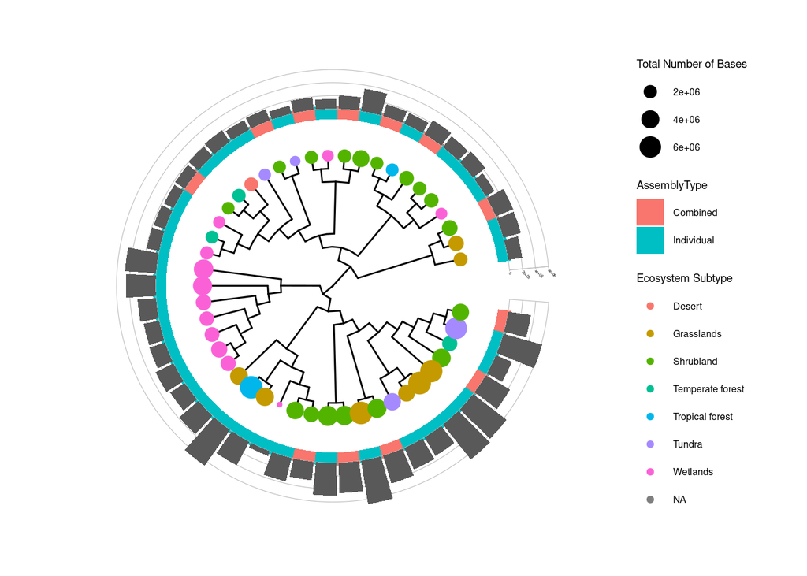

```r
ggtree(tree_Chloroflexota, layout="circular", branch.length="none") %<+%
  NEON_MAGs_metagenomes_chemistry +
  geom_point2(mapping=aes(color=`Ecosystem Subtype`, size=`Total Number of Bases`)) +
  new_scale_fill() +
  geom_fruit(
      data=NEON_MAGs_metagenomes_chemistry_noblank,
      geom=geom_tile,
      mapping=aes(y=label, x=1, fill= AssemblyType),
      offset=0.08,   # The distance between external layers, default is 0.03 times of x range of tree.
      pwidth=0.25 # width of the external layer, default is 0.2 times of x range of tree.
      ) +
  new_scale_fill() +
  geom_fruit(
          data=NEON_MAGs_metagenomes_chemistry_noblank,
          geom=geom_col,
          mapping=aes(y=label, x=TotalNumberofBases),
          pwidth=0.4,
          axis.params=list(
                          axis="x", # add axis text of the layer.
                          text.angle=-45, # the text size of axis.
                          hjust=0  # adjust the horizontal position of text of axis.
                      ),
          grid.params=list() # add the grid line of the external bar plot.
      ) +
      theme(#legend.position=c(0.96, 0.5), # the position of legend.
          legend.background=element_rect(fill=NA), # the background of legend.
          legend.title=element_text(size=7), # the title size of legend.
          legend.text=element_text(size=6), # the text size of legend.
          legend.spacing.y = unit(0.02, "cm")  # the distance of legends (y orientation).
      )
```